# **Machine Learning for Macro Diffusion Indexes**

### Introduction

Macroeconomics (from the Greek prefix makro- meaning “large” + economics) is a branch of economics dealing with the performance, structure, behavior, and decision-making of an economy as a whole. For example, using interest rates, taxes and government spending to regulate an economy’s growth and stability.

The main goal of the project is to help macroeconomists to obtain useful insights from a dataset as a whole with the help of useful Machine Learning Algorithms by creating it’s potential diffusion indexes. Time series analysis is an area of statistics that focuses on analyzing time-dependent data. Time series can be analyzed either descriptively or inferentially. This has led to different approaches depending on the type of information available in time-series data.

We will be using the method proposed by Stock and Watson in their paper called “Macroeconomic Forecasting Using Diffusion Indexes” published in 2002 for generating the forecasts initially and later proceed with the Machine Learning approach.

### Setting Up the R Environment

We will start by calling the required R libraries for Data parsing, processing and manipulation. Here we have used the library, “quantmod” developed by [Joshua Ulrich](https://github.com/joshuaulrich).

```r
require(quantmod)
```

### Parsing the Data

Federal Reserve Economic Data (FRED) is an online database consisting of hundreds of thousands of economic data time series from scores of national, international, public, and private sources. FRED, created and maintained by the Research Department at the Federal Reserve Bank of St. Louis, goes far beyond simply providing data: It combines data with a powerful mix of tools that help the user understand, interact with, display, and disseminate the data. In essence, FRED helps users tell their data stories.

First we’ll create a new environment and a vector object containing the specific names(symbols) of the dataset we will be using.

```r
#Create new environment
fundamental_data <- new.env()
behavioral_data  <- new.env()
catalyst_data    <- new.env()

### Add symbols
symbols1 <- c('AMTMNO', 'AMTMTI', 'OECDLOLITOAASTSAM', 'ICSA', 'INDPRO', 'T10Y2Y', 'BAA10Y', 'MKTGDPHKA646NWDB', 'MKTGDPSGA646NWDB', 'RGDPNABRA666NRUG', # Economic Trend
             'NFCI', # Liquidity
             'M2V', 'TOTCI', 'BOGZ1FA895050005Q' # Velocity
             )

symbols2 <- c('UMCSENT', 'CSUSHPISA', 'SPCS20RSA', # Confirmation Bias: Surveys
              'VIXCLS', 'VXVCLS', 'EVZCLS', 'THREEFYTP10', # Representative Bias
              'EMVOVERALLEMV', # Cognitive Dissonance
              'BOGZ1FA483064105Q' # Overconfidence
              )

symbols3 <- c('CFNAIMA3', 'STLFSI2', # Economic Surprise
              'WLEMUINDXD' # Geopolitics
              )
```

Now we will be using the ‘getSymbols()’ function of the ‘quantmod’ package in order to import the required dataset from fred. The downloaded data will be stored in the form of xts timeseries object in the specified environment.

```r
### Get data
getSymbols(Symbols = symbols1,
           src='FRED',
           env = fundamental_data)
```

```
#> 'getSymbols' currently uses auto.assign=TRUE by default, but will
#> use auto.assign=FALSE in 0.5-0. You will still be able to use
#> 'loadSymbols' to automatically load data. getOption("getSymbols.env")
#> and getOption("getSymbols.auto.assign") will still be checked for
#> alternate defaults.
#>
#> This message is shown once per session and may be disabled by setting
#> options("getSymbols.warning4.0"=FALSE). See ?getSymbols for details.
#>  [1] "AMTMNO"            "AMTMTI"            "OECDLOLITOAASTSAM"
#>  [4] "ICSA"              "INDPRO"            "T10Y2Y"
#>  [7] "BAA10Y"            "MKTGDPHKA646NWDB"  "MKTGDPSGA646NWDB"
#> [10] "RGDPNABRA666NRUG"  "NFCI"              "M2V"
#> [13] "TOTCI"             "BOGZ1FA895050005Q"
```

```r
getSymbols(Symbols = symbols2,
           src='FRED',
           env = behavioral_data)
```

```
#> [1] "UMCSENT"           "CSUSHPISA"         "SPCS20RSA"
#> [4] "VIXCLS"            "VXVCLS"            "EVZCLS"
#> [7] "THREEFYTP10"       "EMVOVERALLEMV"     "BOGZ1FA483064105Q"
```

```r
getSymbols(Symbols = symbols3,
           src='FRED',
           env = catalyst_data)
```

```
#> [1] "CFNAIMA3"   "STLFSI2"    "WLEMUINDXD"
```

```r
rm(symbols1)
rm(symbols2)
rm(symbols3)
```

We are also using some *CSV* datasets in out forecasts, Below is an example if you want to include any csv files you prefer.

Note: Please change the file directory below to select your preferred CSV files from your local storage respectively.

```r
## Get CSV Data

#fundamental
csvfiles <- list.files(path = "~/Documents/Rishi/GSoC_2021/Bloomberg-Dataset/GSOC_macro_Bloomberg_data/Fundamental")
for(i in 1:length(csvfiles)) {
  temp = read.csv(paste0("~/Documents/Rishi/GSoC_2021/Bloomberg-Dataset/GSOC_macro_Bloomberg_data/Fundamental/", csvfiles[i]))
  temp$Date = as.Date(temp$Date, format ="%m-%d-%Y")
  temp <- xts(temp[,2, drop = FALSE], order.by = as.Date(temp[,1], format = "%Y-%m-%d"))
  assign(x = paste0('data', i), value = temp, envir = fundamental_data)
}

#behavioral
csvfiles <- list.files(path = "~/Documents/Rishi/GSoC_2021/Bloomberg-Dataset/GSOC_macro_Bloomberg_data/Behavioral")
for(i in 1:length(csvfiles)) {
  temp = read.csv(paste0("~/Documents/Rishi/GSoC_2021/Bloomberg-Dataset/GSOC_macro_Bloomberg_data/Behavioral/", csvfiles[i]))
  temp$Date = as.Date(temp$Date, format ="%m-%d-%Y")
  temp <- xts(temp[,2, drop = FALSE], order.by = as.Date(temp[,1], format = "%Y-%m-%d"))
  assign(x = paste0('data', i), value = temp, envir = behavioral_data)
}

#catalyst
csvfiles <- list.files(path = "~/Documents/Rishi/GSoC_2021/Bloomberg-Dataset/GSOC_macro_Bloomberg_data/Catalyst")
for(i in 1:length(csvfiles)) {
  temp = read.csv(paste0("~/Documents/Rishi/GSoC_2021/Bloomberg-Dataset/GSOC_macro_Bloomberg_data/Catalyst/", csvfiles[i]))
  temp$Date = as.Date(temp$Date, format ="%m-%d-%Y")
  temp <- xts(temp[,2, drop = FALSE], order.by = as.Date(temp[,1], format = "%Y-%m-%d"))
  assign(x = paste0('data', i), value = temp, envir = catalyst_data)
}
```

Now we are going to merge all the datasets stored in our environments into *lists* to further operate on it easily.

```r
### Merge data - this will store it in a list
data_fundamental <- eapply(env = fundamental_data, FUN = merge.xts)
data_behavioral  <- eapply(env = behavioral_data, FUN = merge.xts)
data_catalyst    <- eapply(env = catalyst_data, FUN = merge.xts)

#clean-up
rm(temp)
rm(i)
```

### Data Preprocessing

We will start by checking the *Periodicities* of all the Datasets which we have considered to get a clear insight.

```r
## Check Periodicities
# Fundamental
ls_fun_periodicities <- lapply(data_fundamental, periodicity)
fun_periodicities <- as.data.frame(do.call(rbind, lapply(data_fundamental, periodicity)))
fun_periodicities$start <- as.Date(sapply(ls_fun_periodicities, "[[", 3))
fun_periodicities$end <- as.Date(sapply(ls_fun_periodicities, "[[", 4))
fun_periodicities
```

```
#>                   difftime frequency      start        end units     scale
#> OECDLOLITOAASTSAM  2678400   2678400 1961-06-01 2021-07-01  days   monthly
#> data1              2678400   2678400 2001-08-31 2021-06-30  days   monthly
#> data2               604800    604800 2006-01-06 2021-05-07  days    weekly
#> data3                86400     86400 2003-01-02 2021-05-18  days     daily
#> data4              2678400   2678400 2005-01-31 2021-04-30  days   monthly
#> MKTGDPHKA646NWDB  31536000  31536000 1960-01-01 2020-01-01  days    yearly
#> data5                86400     86400 2002-02-06 2021-05-18  days     daily
#> BAA10Y               86400     86400 1986-01-02 2021-08-19  days     daily
#> MKTGDPSGA646NWDB  31536000  31536000 1960-01-01 2020-01-01  days    yearly
#> data6              2678400   2678400 2004-02-29 2021-04-30  days   monthly
#> data7              2678400   2678400 2005-01-31 2021-05-31  days   monthly
#> data8               604800    604800 1990-07-27 2021-07-09  days    weekly
#> AMTMTI             2678400   2678400 1992-01-01 2021-06-01  days   monthly
#> T10Y2Y               86400     86400 1976-06-01 2021-08-20  days     daily
#> data9               604800    604800 1990-01-05 2021-07-09  days    weekly
#> NFCI                604800    604800 1971-01-08 2021-08-13  days    weekly
#> AMTMNO             2678400   2678400 1992-02-01 2021-06-01  days   monthly
#> RGDPNABRA666NRUG  31536000  31536000 1950-01-01 2019-01-01  days    yearly
#> TOTCI               604800    604800 1973-01-03 2021-08-11  days    weekly
#> ICSA                604800    604800 1967-01-07 2021-08-14  days    weekly
#> data10             2678400   2678400 1996-01-31 2021-06-30  days   monthly
#> M2V                7862400   7862400 1959-01-01 2021-04-01  days quarterly
#> data11             2678400   2678400 1980-07-31 2021-05-31  days   monthly
#> BOGZ1FA895050005Q  7948800   7948800 1946-10-01 2021-01-01  days quarterly
#> data12               86400     86400 1998-05-18 2021-05-18  days     daily
#> data13               86400     86400 1990-01-31 2021-05-18  days     daily
#> INDPRO             2678400   2678400 1919-01-01 2021-07-01  days   monthly
#> data14             2678400   2678400 1981-05-31 2021-04-30  days   monthly
#> data15               86400     86400 1990-01-31 2021-05-18  days     daily
#>                     label
#> OECDLOLITOAASTSAM   month
#> data1               month
#> data2                week
#> data3                 day
#> data4               month
#> MKTGDPHKA646NWDB     year
#> data5                 day
#> BAA10Y                day
#> MKTGDPSGA646NWDB     year
#> data6               month
#> data7               month
#> data8                week
#> AMTMTI              month
#> T10Y2Y                day
#> data9                week
#> NFCI                 week
#> AMTMNO              month
#> RGDPNABRA666NRUG     year
#> TOTCI                week
#> ICSA                 week
#> data10              month
#> M2V               quarter
#> data11              month
#> BOGZ1FA895050005Q quarter
#> data12                day
#> data13                day
#> INDPRO              month
#> data14              month
#> data15                day
```

```r
# Behavioral
ls_beh_periodicities <- lapply(data_behavioral, periodicity)
beh_periodicities <- as.data.frame(do.call(rbind, lapply(data_behavioral, periodicity)))
beh_periodicities$start <- as.Date(sapply(ls_beh_periodicities, "[[", 3))
beh_periodicities$end <- as.Date(sapply(ls_beh_periodicities, "[[", 4))
beh_periodicities
```

```
#>                   difftime frequency      start        end units     scale
#> data16               86400     86400 1990-05-14 2021-05-14  days     daily
#> EVZCLS               86400     86400 2007-11-01 2021-08-19  days     daily
#> data1                86400     86400 2000-06-29 2021-06-28  days     daily
#> SPCS20RSA          2678400   2678400 2000-01-01 2021-05-01  days   monthly
#> data2               604800    604800 1991-01-11 2021-08-01  days    weekly
#> data3                86400     86400 1996-08-22 2021-07-12  days     daily
#> data4              2678400   2678400 1990-05-31 2021-04-30  days   monthly
#> THREEFYTP10          86400     86400 1990-01-02 2021-08-13  days     daily
#> data5                86400     86400 1994-11-09 2021-07-09  days     daily
#> VIXCLS               86400     86400 1990-01-02 2021-08-19  days     daily
#> VXVCLS               86400     86400 2007-12-04 2021-08-19  days     daily
#> BOGZ1FA483064105Q  7948800   7948800 1946-10-01 2021-01-01  days quarterly
#> data6                86400     86400 2005-08-31 2021-05-17  days     daily
#> data7                86400     86400 1981-05-31 2021-05-17  days     daily
#> EMVOVERALLEMV      2678400   2678400 1985-01-01 2021-07-01  days   monthly
#> data8               604800    604800 1991-05-26 2018-11-18  days    weekly
#> data9                86400     86400 2007-01-03 2020-11-20  days     daily
#> UMCSENT            2678400   2678400 1952-11-01 2021-06-01  days   monthly
#> CSUSHPISA          2678400   2678400 1987-01-01 2021-05-01  days   monthly
#> data10               86400     86400 1988-04-04 2021-07-12  days     daily
#> data11             2678400   2678400 1990-05-31 2021-04-30  days   monthly
#> data12               86400     86400 1990-01-02 2021-07-09  days     daily
#> data13               86400     86400 1999-04-16 2021-05-18  days     daily
#> data14               86400     86400 2000-01-10 2021-06-10  days     daily
#> data15              604800    604800 2001-05-18 2021-05-14  days    weekly
#>                     label
#> data16                day
#> EVZCLS                day
#> data1                 day
#> SPCS20RSA           month
#> data2                week
#> data3                 day
#> data4               month
#> THREEFYTP10           day
#> data5                 day
#> VIXCLS                day
#> VXVCLS                day
#> BOGZ1FA483064105Q quarter
#> data6                 day
#> data7                 day
#> EMVOVERALLEMV       month
#> data8                week
#> data9                 day
#> UMCSENT             month
#> CSUSHPISA           month
#> data10                day
#> data11              month
#> data12                day
#> data13                day
#> data14                day
#> data15               week
```

```r
# Catalyst
ls_cat_periodicities <- lapply(data_catalyst, periodicity)
cat_periodicities <- as.data.frame(do.call(rbind, lapply(data_catalyst, periodicity)))
cat_periodicities$start <- as.Date(sapply(ls_cat_periodicities, "[[", 3))
cat_periodicities$end <- as.Date(sapply(ls_cat_periodicities, "[[", 4))
cat_periodicities
```

```
#>            difftime frequency      start        end units     scale   label
#> STLFSI2      604800    604800 1993-12-31 2021-08-13  days    weekly    week
#> WLEMUINDXD    86400     86400 1985-01-01 2021-08-19  days     daily     day
#> CFNAIMA3    2678400   2678400 1967-05-01 2021-06-01  days   monthly   month
#> data1         86400     86400 2003-01-01 2021-05-18  days     daily     day
#> data2       7948800   7948800 1992-03-31 2020-12-31  days quarterly quarter
#> data3         86400     86400 1990-01-31 2021-05-18  days     daily     day
#> data4         86400     86400 1999-12-20 2021-05-17  days     daily     day
```

We will proceed by converting the datasets to monthly, At this point it gives us warning messages about missing values being removed. We will ignore this for now.

```r
## Convert into Monthly
data_fin_1 <- lapply(data_fundamental, to.monthly, OHLC=FALSE)
```

```
#> Warning in to.period(x, "months", indexAt = indexAt, name = name, ...): missing
#> values removed from data
```

```
#> Warning in to.period(x, "months", indexAt = indexAt, name = name, ...): missing
#> values removed from data
```

```r
data_fin_2 <- lapply(data_behavioral, to.monthly, OHLC=FALSE)





data_fin_3 <- lapply(data_catalyst, to.monthly, OHLC=FALSE)

#clean-up
rm(data_fundamental)
rm(data_behavioral)
rm(data_catalyst)
```

Now we need to remove/fill all the *NA* values in our datasets as we can’t move forward with the forecasts with incomplete data.

```r
#merge data
xts_data_fun <- do.call(merge.xts, data_fin_1)

xts_data_fun <- na.locf(xts_data_fun, na.rm = TRUE)

xts_data_beh <- do.call(merge.xts, data_fin_2)
xts_data_beh <- na.locf(xts_data_beh, na.rm = TRUE)

xts_data_cat <- do.call(merge.xts, data_fin_3)
xts_data_cat <- na.locf(xts_data_cat, na.rm = TRUE)
```

We further align our Datasets a bit to have common starting point and maintain uniformity across all the datasets.

```r
## Align Data
xts_data_fun <- xts_data_fun["2007-12/"]
xts_data_beh <- xts_data_beh["2007-12/"]
xts_data_cat <- xts_data_cat["2007-12/"]


#clean-up
rm(data_fin_1)
rm(data_fin_2)
rm(data_fin_3)
```

Now we have used and altered the SWfore function from the package [MTS] (https://cran.r-project.org/web/packages/MTS/index.html)

```r
## Using SWFore to build Diffusion Indexes - Function
"DiffIdx" <- function(x,orig,m){
  ### Builds Stock and Watson's diffusion index prediction
  ### x: observed regressors
  ### orig: forecast origin
  ### m: selected number of PCs
  ###
  ### Output: Forecasts and MSE of forecasts (if data available)
  if(!is.matrix(x))x=as.matrix(x)
  nT=dim(x)[1]
  k=dim(x)[2]
  if(orig > nT)orig=nT
  if(m > k)m=k; if(m < 1)m=1
  # standardize the predictors
  x1=x[1:orig,]
  me=apply(x1,2,mean)
  se=sqrt(apply(x1,2,var))
  x1=x
  for (i in 1:k){
    x1[,i]=(x1[,i]-me[i])/se[i]
  }
  #
  V1=cov(x1[1:orig,])
  m1=eigen(V1)
  sdev=m1$values
  M=m1$vectors
  M1=M[,1:m]
  Dindex=x1%*%M1
  # y1=y[1:orig]
  # DF=Dindex[1:orig,]
  DF=Dindex
  # mm=lm(y1~DF)
  # coef=matrix(mm$coefficients,(m+1),1)
  # coef=matrix(mm$coefficients[-1],(m),1) # exclude the intercept
  #cat("coefficients: ","\n")
  #print(round(coef,4))
  yhat=NULL; MSE=NULL
  # if(orig < nT){
  #    newx=cbind(rep(1,(nT-orig)),Dindex[(orig+1):nT,])
  #    yhat=mm$coefficients[1]+(t(newx)%*%coef)
  #    err=y[(orig+1):nT]-yhat
  #    MSE=mean(err^2)
  #    cat("MSE of out-of-sample forecasts: ",MSE,"\n")
  # }

  DiffIdx <- xts(DF, index(x1))
}
```

### Constructing the Diffusion Indexes

```r
#Constructing Diffusion Index

#fundamental
fundamental_DI <- DiffIdx(xts_data_fun, orig = nrow(xts_data_fun), m = 1)
head(fundamental_DI)
```

```
#>              [,1]
#> Dec 2007 3.174667
#> Jan 2008 3.497397
#> Feb 2008 3.669119
#> Mar 2008 3.933509
#> Apr 2008 3.535863
#> May 2008 3.346542
```

```r
#behavioral
behavioral_DI <- DiffIdx(xts_data_beh, orig = nrow(xts_data_beh), m = 1)
head(behavioral_DI)
```

```
#>               [,1]
#> Dec 2007 -1.899544
#> Jan 2008 -2.915343
#> Feb 2008 -3.283700
#> Mar 2008 -3.836749
#> Apr 2008 -2.803471
#> May 2008 -2.811009
```

```r
#catalyst
catalyst_DI <- DiffIdx(xts_data_cat, orig = nrow(xts_data_cat), m = 1)
head(catalyst_DI)
```

```
#>               [,1]
#> Dec 2007 -1.496111
#> Jan 2008 -1.688609
#> Feb 2008 -1.893986
#> Mar 2008 -1.738865
#> Apr 2008 -2.262543
#> May 2008 -1.424913
```

Now we make some visualizations of our Diffusion Indexes to get more insights.

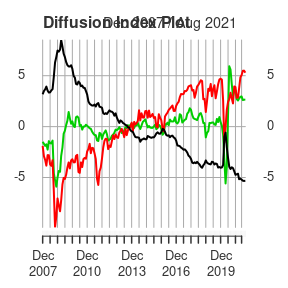

```r
## Plot DI(s)
plot_data <- cbind(fundamental_DI, behavioral_DI, catalyst_DI)
plot(plot_data, main = "Diffusion Index Plot")
```

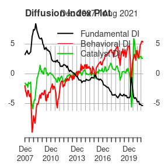

```r
addLegend("topright", on=1,
          legend.names = c("Fundamental DI", "Behavioral DI", "Catalyst DI"),
          lty=c(1, 1), lwd=c(2, 1))
```

We further move on to scale our data. We will be using the package ‘roll’ to scale our data by calculating the Z-scores.

```r
#Scaling & Standardizing the observation
library(roll)
x <- plot_data # we can use plot_data...it is complete
x$DI <- rowMeans(coredata(plot_data))
scaled_DI <- roll_scale(x, width = 5, na_restore = FALSE)
```

Now we quickly plot our scaled Diffusion Indexes to get a rough visualization.

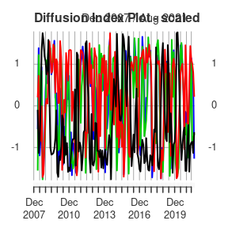

```r
# Plot Scaled DI(s)
plot(scaled_DI, main = "Diffusion Index Plot - scaled")
```

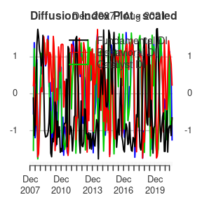

```r
addLegend("topright", on=1,
          legend.names = c("Fundamental DI", "Behavioral DI", "Catalyst DI"),
          lty=c(1, 1), lwd=c(2, 1))
```

We have chosen to make forecasts of S&P 500 from our Diffusion Indexes. The Standard and Poor’s 500, or simply the S&P 500, is a stock market index tracking the performance of 500 large companies listed on stock exchanges in the United States. It is one of the most commonly followed equity indices.

Here we get our S&P 500 data, change it to monthly data and calculate it’s returns.

```r
## Getting S&P 500 Data
SP_500 <- getSymbols (Symbols = 'SPY', src= 'yahoo', auto.assign = FALSE)

library(PerformanceAnalytics)
SP_500_period <- to.monthly(SP_500)

# We get data starting Jan 2007 for the S&P 500, so we remove everything before Dec 2007, the start of the Diffusion Indexes
SP_500_period <- SP_500_period["2007-12/"]
#Calculate S&P Returns
x$SPR <- Return.calculate(Ad(SP_500_period))
```

Now it’s time to check the correlation between our Diffusion Indexes and the S&P 500 Data. We plot a scatter plot to get a quick rough idea, Further, we go on calculating the lags of our Input Data.

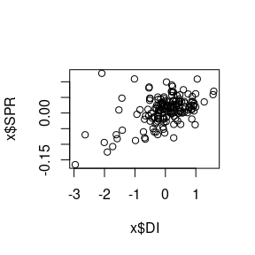

```r
# Plot DI vs S&P 500
plot.default(x$DI, x$SPR)
```

```r
## Lagging Values

xl <- merge(x$DI, scaled_DI)
diff.lookbacks <- 1:12
xl_lagged <- do.call(cbind, lapply(diff.lookbacks, function(n) lag(xl, k = n)))
head(xl_lagged, 12) # Use up to 12 lags...considering this is monthly data, 12m feels adequate
```

```
#>                  DI fundamental_DI behavioral_DI catalyst_DI       DI.1
#> Dec 2007         NA             NA            NA          NA         NA
#> Jan 2008 -0.0736625             NA            NA          NA         NA
#> Feb 2008 -0.3688516             NA            NA          NA         NA
#> Mar 2008 -0.5028553             NA            NA          NA         NA
#> Apr 2008 -0.5473684             NA            NA          NA         NA
#> May 2008 -0.5100501    -0.09515175   0.202854334  -1.5546079 -0.5619205
#> Jun 2008 -0.2964601    -1.13252973   0.723622493   1.2233737  1.3874306
#> Jul 2008 -0.6601800    -0.84129242  -0.876268344   0.5078443 -1.1905440
#> Aug 2008 -0.6510687     0.02949582  -0.820141616   0.2811938 -0.8013331
#> Sep 2008 -0.3299190     1.32689255  -0.009131989   0.8360223  0.9277962
#> Oct 2008 -2.0073352     1.74825456  -1.709275688  -1.7816605 -1.7346092
#> Nov 2008 -2.9604213     1.55518871  -1.611946875  -1.2685606 -1.4617742
#>                DI.2 fundamental_DI.1 behavioral_DI.1 catalyst_DI.1     DI.1.1
#> Dec 2007         NA               NA              NA            NA         NA
#> Jan 2008         NA               NA              NA            NA         NA
#> Feb 2008 -0.0736625               NA              NA            NA         NA
#> Mar 2008 -0.3688516               NA              NA            NA         NA
#> Apr 2008 -0.5028553               NA              NA            NA         NA
#> May 2008 -0.5473684               NA              NA            NA         NA
#> Jun 2008 -0.5100501      -0.09515175     0.202854334    -1.5546079 -0.5619205
#> Jul 2008 -0.2964601      -1.13252973     0.723622493     1.2233737  1.3874306
#> Aug 2008 -0.6601800      -0.84129242    -0.876268344     0.5078443 -1.1905440
#> Sep 2008 -0.6510687       0.02949582    -0.820141616     0.2811938 -0.8013331
#> Oct 2008 -0.3299190       1.32689255    -0.009131989     0.8360223  0.9277962
#> Nov 2008 -2.0073352       1.74825456    -1.709275688    -1.7816605 -1.7346092
#>                DI.3 fundamental_DI.2 behavioral_DI.2 catalyst_DI.2     DI.1.2
#> Dec 2007         NA               NA              NA            NA         NA
#> Jan 2008         NA               NA              NA            NA         NA
#> Feb 2008         NA               NA              NA            NA         NA
#> Mar 2008 -0.0736625               NA              NA            NA         NA
#> Apr 2008 -0.3688516               NA              NA            NA         NA
#> May 2008 -0.5028553               NA              NA            NA         NA
#> Jun 2008 -0.5473684               NA              NA            NA         NA
#> Jul 2008 -0.5100501      -0.09515175     0.202854334    -1.5546079 -0.5619205
#> Aug 2008 -0.2964601      -1.13252973     0.723622493     1.2233737  1.3874306
#> Sep 2008 -0.6601800      -0.84129242    -0.876268344     0.5078443 -1.1905440
#> Oct 2008 -0.6510687       0.02949582    -0.820141616     0.2811938 -0.8013331
#> Nov 2008 -0.3299190       1.32689255    -0.009131989     0.8360223  0.9277962
#>                DI.4 fundamental_DI.3 behavioral_DI.3 catalyst_DI.3     DI.1.3
```

[output cut: 101 more lines]

```
#> Oct 2008         NA                NA               NA             NA      NA
#> Nov 2008 -0.0736625                NA               NA             NA      NA
#>          DI.12 fundamental_DI.11 behavioral_DI.11 catalyst_DI.11 DI.1.11
#> Dec 2007    NA                NA               NA             NA      NA
#> Jan 2008    NA                NA               NA             NA      NA
#> Feb 2008    NA                NA               NA             NA      NA
#> Mar 2008    NA                NA               NA             NA      NA
#> Apr 2008    NA                NA               NA             NA      NA
#> May 2008    NA                NA               NA             NA      NA
#> Jun 2008    NA                NA               NA             NA      NA
#> Jul 2008    NA                NA               NA             NA      NA
#> Aug 2008    NA                NA               NA             NA      NA
#> Sep 2008    NA                NA               NA             NA      NA
#> Oct 2008    NA                NA               NA             NA      NA
#> Nov 2008    NA                NA               NA             NA      NA
```

### Applying the Machine Learning Algorithm(s)

We have decided to use different ML Algo’s to train and make forecasts, our primary algorithm as of now is Random Forest with approximately 72% accuracy. We further aim on improving the alogrithms and comparing the relative performances.

We have used the caret package (short for Classification And Regression Training) which contains functions to streamline the model training process for complex regression and classification problems.

Here we first load all the required packages then use one hot encoding and try to convert the S&P 500 dataset into a binary dataset. This allows us to successfully carry out our Random Forest classification or any other related methods. Then we split our data into training and testing with 80:20 ratio and train on the first 80% of our data with the remaining to test and make forecasts.

```r
library(doParallel)
library(caret)
# Tuning S&P 500
ret_SP500 <- Return.calculate(Ad(SP_500_period))
one_hot_ret_SP500 <- ifelse(ret_SP500 > 0, 1, 0)
newdata <- cbind(xl_lagged, one_hot_ret_SP500)
newdata1 <- data.frame(newdata)
newdata1$SP_500.Adjusted <- as.factor(newdata1$SP_500.Adjusted)

## Split Data
train.perc = 0.8
train.indx = 1:as.integer(dim(newdata1)[1] * train.perc)

train.data <- newdata1[train.indx,]
test.data  <- newdata1[-train.indx ,]

set.seed(125)

## Tuning
myTimeControl <- trainControl(method = "timeslice",
                              initialWindow = 36,
                              horizon = 12,
                              fixedWindow = FALSE,
                              allowParallel = TRUE,
                              verboseIter = TRUE)

# tune_grid <- expand.grid(nrounds = 200,
#                         max_depth = 5,
#                         eta = 0.05,
#                         gamma = 0.01,
#                         colsample_bytree = 0.75,
#                         min_child_weight = 0,
#                         subsample = 0.5)
#
# trctrl <- trainControl(method = "cv", number = 5) #Code for xgboost


## Training
tuneLength.num <- 5
mod.rf <- train(SP_500.Adjusted ~ .,
                    data = train.data,
                    method = "ranger",
                    trControl = myTimeControl,
                    tuneLength = tuneLength.num,
                    na.action = na.exclude)
```

```
#> Warning in nominalTrainWorkflow(x = x, y = y, wts = weights, info = trainInfo, :
#> There were missing values in resampled performance measures.
```

```r
# mod.xg <- train(SP_500.Adjusted ~ .,
#                 train.data,
#                 method = "xgbTree",
#                 trControl = trctrl,
#                 tuneGrid = tune_grid,
#                 tuneLength = 10,
#                 na.action = na.exclude)  #Code for xgboost

mod.rf$results
```

```
#>    mtry min.node.size  splitrule  Accuracy       Kappa AccuracySD    KappaSD
#> 1     2             1       gini 0.7258454 -0.02064838 0.14082902 0.04848756
#> 2     2             1 extratrees 0.7355072 -0.01156344 0.14917839 0.03692569
#> 3    16             1       gini 0.7053140 -0.02567642 0.10750029 0.10125371
#> 4    16             1 extratrees 0.7113527 -0.04274708 0.14332914 0.08178710
#> 5    31             1       gini 0.7077295 -0.01494191 0.10367353 0.11358892
#> 6    31             1 extratrees 0.6956522 -0.05308443 0.13006573 0.08846640
#> 7    45             1       gini 0.6980676 -0.02613614 0.10315830 0.11846915
#> 8    45             1 extratrees 0.6956522 -0.05144766 0.12768848 0.08889353
#> 9    60             1       gini 0.6956522 -0.02268542 0.09986315 0.11700410
#> 10   60             1 extratrees 0.6956522 -0.05012933 0.13006573 0.09273416
```

We now get some visualizations of our forecasts, a density, box and scatter plot.

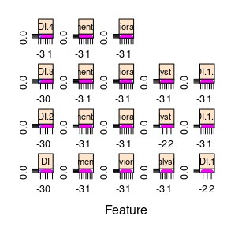

```r
## Visualisations

featurePlot(x = train.data[, 1:18],
            y = train.data$SP_500.Adjusted,
            plot = "density",
            strip=strip.custom(par.strip.text=list(cex=.7)),
            scales = list(x = list(relation="free"),
                          y = list(relation="free")))
```

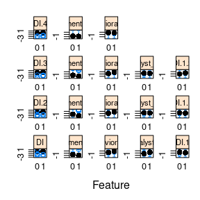

```r
featurePlot(x = train.data[, 1:18],
            y = train.data$SP_500.Adjusted,
            plot = "box",
            strip=strip.custom(par.strip.text=list(cex=.7)),
            scales = list(x = list(relation="free"),
                          y = list(relation="free")))
```

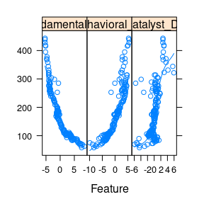

```r
featurePlot(x = x[, 1:3],
            y = SP_500_period$SP_500.Adjusted,
            plot = "scatter",
            type = c("p", "smooth"),
            layout = c(3, 1))
```

Finally we use the predict() function to get further predictions and take a look at it.

```r
## Forecast

pred.rf <- predict(mod.rf, newdata = test.data)
head(pred.rf)
```

```
#> [1] 1 1 1 1 1 1
#> Levels: 0 1
```